# U.S. storm data in relation to population health and economic damage

Patrick Siu

October 22, 2015

# Synopsis

Storms and other severe weather events can cause both public health and economic problems for communities and municipalities. Many severe events can result in fatalities, injuries, and property damage, and preventing such outcomes to the extent possible is a key concern.

By looking at the U.S. National Oceanic and Atmospheric Administration (NOAA) data, we were able to surface the following insights:

- Population health:
  - When it comes to weather driven events, the top cause of fatalities is due to excessive heat. 1903 fatalities were recorded between 1995 - 2011.
  - When considering injuries, tornados are a significant health hazard with a recorded 21,765 injuries and 1545 fatalities between 1995-2011.
- Economic damage:
  - Floods cause the greatest economic consequences when considering property damage and crop damage. Totalling in $149 billion USD in property and crop damage from 1995-2011.

# Data Processing

## Libraries utilized:

```r
library(lubridate)
library(dplyr)
library(ggplot2)
library(gridExtra)
library(printr)

##Suppress scientific notation
options(scipen=999)
```

## Loading the raw data

```r
rawDataFile <- "repdata-data-StormData.csv.bz2"
downloadURL <- "https://github.com/psiu/RepData_PeerAssessment2/raw/master/repdata-data-StormData.csv.bz2"

##Ensure raw data file exists
if(!file.exists(rawDataFile)){
    download.file(downloadURL, rawDataFile)
}

##Load raw data
noaa <- read.csv(rawDataFile, stringsAsFactors = FALSE, na.strings = c("", "NA"), strip.white = TRUE, colClasses = c(EVTYPE ="factor"))

noaa <- tbl_df(noaa)
```

## Processing the data to form the tidy data set

```r
##Helper function to calculate exponents
exp_calc <- function(exp = "") {
    if(is.na(exp))
        return (1)
    else if(exp == "B" | exp == "b")
        return (1000000000)
    else if(exp == "M" | exp == "m")
        return (1000000)
    else if(exp == "K" | exp == "k")
        return (1000)
    else return (1)
}

##Convert exponent to actual numbers
noaa$PROPDMGEXP_NUM <- sapply(noaa$PROPDMGEXP, exp_calc)
noaa$CROPDMGEXP_NUM <- sapply(noaa$CROPDMGEXP, exp_calc)

noaa <- noaa %>% mutate(propdamage = PROPDMG * PROPDMGEXP_NUM) %>% mutate(cropdamage = CROPDMG * CROPDMGEXP_NUM)

##Format column
noaa$BGN_DATE <- mdy_hms(noaa$BGN_DATE)
##Extract just the year of the event
noaa$Year <- year(noaa$BGN_DATE)

##Express the monetary value in billions
noaa$propdamage <- noaa$propdamage / 1000000000
noaa$cropdamage <- noaa$cropdamage / 1000000000

##Select relevant columns for analysis
noaa <- noaa %>% select(Year, EVTYPE, FATALITIES, INJURIES, propdamage, cropdamage)
```

The tidy data set “noaa” is ready for analysis.

# Analysis

## Subsetting the data from 1995 - 2011 to eliminate outliers

The events in the database start in the year 1950 and end in November 2011. In the earlier years of the database there are generally fewer events recorded, most likely due to a lack of good records. Let’s take a look at the number of events with a histogram:

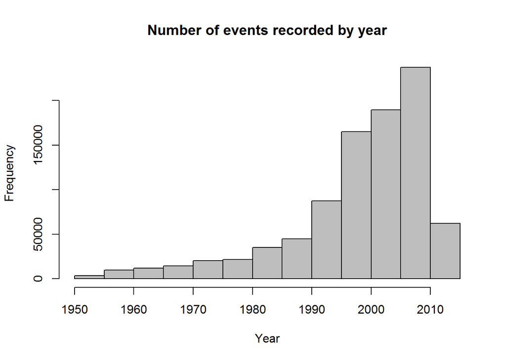

```r
hist(noaa$Year, main = "Number of events recorded by year", xlab = "Year", col = "gray")
```

```r
year_print <- as.data.frame(noaa$Year)
colnames(year_print) <- "Year Distribution Stats"
summary(year_print)
```

|  | Year Distribution Stats |
| --- | --- |
|  | Min. :1950 |
|  | 1st Qu.:1995 |
|  | Median :2002 |
|  | Mean :1999 |
|  | 3rd Qu.:2007 |
|  | Max. :2011 |

By summarizing the year in which the events were recorded, we can see a significant difference in the number of events recorded before and after 1995. To eliminate the bias driven by outliers, we will subset the data from the 1st quartile, which is year 1995 onwards.

### Determine the top events that cause fatalities

```r
fatalities <- noaa %>% filter(Year > 1994) %>% group_by(EVTYPE) %>% summarize(FATALITIES = sum(FATALITIES), INJURIES = sum(INJURIES)) %>% arrange(desc(FATALITIES))

#Take only top 10 rows
fatalities <- fatalities[1:10,]

fatalities
```

| EVTYPE | FATALITIES | INJURIES |
| --- | --- | --- |
| EXCESSIVE HEAT | 1903 | 6525 |
| TORNADO | 1545 | 21765 |
| FLASH FLOOD | 934 | 1734 |
| HEAT | 924 | 2030 |
| LIGHTNING | 729 | 4631 |
| FLOOD | 423 | 6769 |
| RIP CURRENT | 360 | 227 |
| HIGH WIND | 241 | 1093 |
| TSTM WIND | 241 | 3630 |
| AVALANCHE | 223 | 159 |

### Determine the top events that cause injuries

```r
injuries <- noaa %>% filter(Year > 1994) %>% group_by(EVTYPE) %>% summarize(FATALITIES = sum(FATALITIES), INJURIES = sum(INJURIES)) %>% arrange(desc(INJURIES))

#Take only top 10 rows
injuries <- injuries[1:10,]

injuries
```

| EVTYPE | FATALITIES | INJURIES |
| --- | --- | --- |
| TORNADO | 1545 | 21765 |
| FLOOD | 423 | 6769 |
| EXCESSIVE HEAT | 1903 | 6525 |
| LIGHTNING | 729 | 4631 |
| TSTM WIND | 241 | 3630 |
| HEAT | 924 | 2030 |
| FLASH FLOOD | 934 | 1734 |
| THUNDERSTORM WIND | 131 | 1426 |
| WINTER STORM | 195 | 1298 |
| HURRICANE/TYPHOON | 64 | 1275 |

### Determine the top events for property damage

```r
prop <- noaa %>% filter(Year > 1994) %>% group_by(EVTYPE) %>% summarize(propdamage = sum(propdamage)) %>% arrange(desc(propdamage))

#Take only top 10 rows
prop <- prop[1:10,]

prop
```

| EVTYPE | propdamage |
| --- | --- |
| FLOOD | 144.022037 |
| HURRICANE/TYPHOON | 69.305840 |
| STORM SURGE | 43.193536 |
| TORNADO | 24.925720 |
| FLASH FLOOD | 15.365933 |
| HAIL | 15.045722 |
| HURRICANE | 11.812819 |
| TROPICAL STORM | 7.653336 |
| HIGH WIND | 5.259785 |
| WILDFIRE | 4.759064 |

### Determine the top events for crop damage

```r
crop <- noaa %>% filter(Year > 1994) %>% group_by(EVTYPE) %>% summarize(cropdamage = sum(cropdamage)) %>% arrange(desc(cropdamage))

#Take only top 10 rows
crop <- crop[1:10,]

crop
```

| EVTYPE | cropdamage |
| --- | --- |
| DROUGHT | 13.9220660 |
| FLOOD | 5.4228104 |
| HURRICANE | 2.7414100 |
| HAIL | 2.6141271 |
| HURRICANE/TYPHOON | 2.6078728 |
| FLASH FLOOD | 1.3439150 |
| EXTREME COLD | 1.2924730 |
| FROST/FREEZE | 1.0940860 |
| HEAVY RAIN | 0.7283998 |
| TROPICAL STORM | 0.6778360 |

# Results

## Across the United States, which types of events are most harmful with respect to population health?

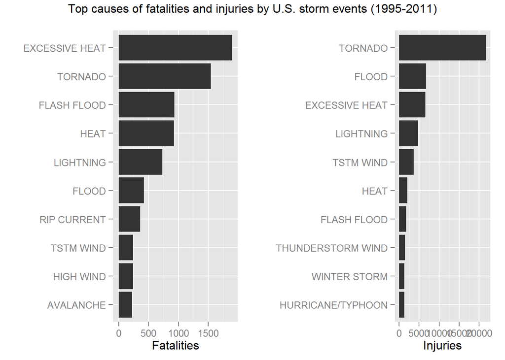

```r
fig2_a <- ggplot(fatalities, aes(x = reorder(EVTYPE, FATALITIES), y = FATALITIES)) +
    geom_bar(stat= "identity") +
    coord_flip() +
    labs (y = "Fatalities", x = "")

fig2_b <- ggplot(injuries, aes(x = reorder(EVTYPE, INJURIES), y = INJURIES)) +
    geom_bar(stat= "identity") +
    coord_flip() +
    labs (y = "Injuries", x = "")

grid.arrange(fig2_a, fig2_b, nrow = 1 , top = "Top causes of fatalities and injuries by U.S. storm events (1995-2011)")
```

When it comes to weather driven events, the top cause of fatalities is due to excessive heat. 1903 fatalities were recorded between 1995 - 2011.

When considering injuries, tornados are a significant health hazard with a recorded 21,765 injuries and 1545 fatalities between 1995-2011.

## Across the United States, which types of events have the greatest economic consequences?

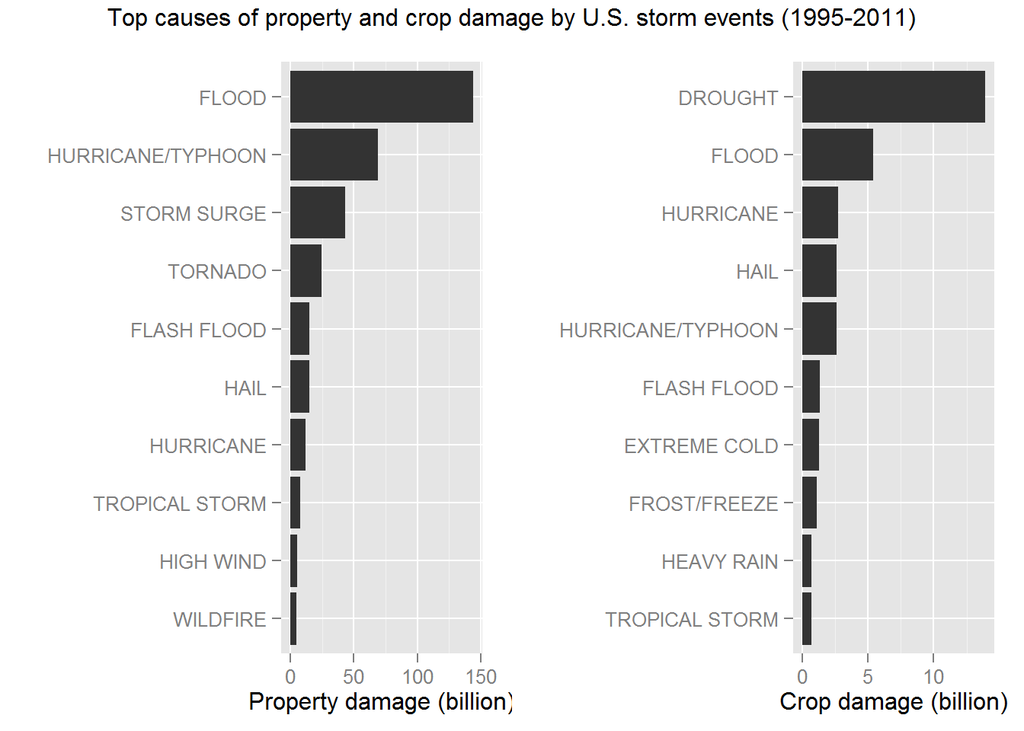

```r
fig3_a <- ggplot(prop, aes(x = reorder(EVTYPE, propdamage), y = propdamage)) +
    geom_bar(stat= "identity") +
    coord_flip() +
    labs (y = "Property damage (billion)", x = "")

fig3_b <- ggplot(crop, aes(x = reorder(EVTYPE, cropdamage), y = cropdamage)) +
    geom_bar(stat= "identity") +
    coord_flip() +
    labs (y = "Crop damage (billion)", x = "")

grid.arrange(fig3_a, fig3_b, nrow = 1, top = "Top causes of property and crop damage by U.S. storm events (1995-2011)")
```

Floods cause the greatest economic consequences when considering property damage and crop damage. Totalling in $149 billion USD in property and crop damage from 1995-2011.